# Example: fitting the deterministic SEITL model

Here is an example of possible answers to the practical on fitting the deterministic SEITL model to the Tristan da Cunha outbreak.

Each section below correspond to a section of the practical. Thus, you can have a look at our example for one section and then go back to the practical to answer the following sections.

Although our example refers to the SEITL model, the same commands work for the SEIT2L model (i.e. `data(SEIT2L_deter)` instead of `data(SEITL_deter)`).

# Setting the MCMC

```r
# the fitmodel
data(SEITL_deter)

# wrapper for posterior
my_posteriorTdC <- function(theta) {

    my_fitmodel <- SEITL_deter
    my_init.state <- c(S = 279, E = 0, I = 2, T = 3, L = 0, Inc = 0)
    # note that for the SEIT2L model there are two state variables for the T
    # compartment my_init.state <- c('S' = 279, 'E' = 0, 'I' = 2, 'T1' = 3, 'T2'
    # = 0, 'L' = 0, 'Inc' = 0)

    return(logPosterior(fitmodel = my_fitmodel, theta = theta, init.state = my_init.state,
        data = FluTdC1971, margLogLike = dTrajObs))

}

# theta to initialise the MCMC
init.theta <- c(R0 = 2, D_lat = 2, D_inf = 2, alpha = 0.8, D_imm = 16, rho = 0.85)

# diagonal elements of the covariance matrix for the Gaussian proposal
proposal.sd <- c(R0 = 1, D_lat = 0.5, D_inf = 0.5, alpha = 0.1, D_imm = 2, rho = 0.1)

# lower and upper limits of each parameter
lower <- c(R0 = 0, D_lat = 0, D_inf = 0, alpha = 0, D_imm = 0, rho = 0)
upper <- c(R0 = Inf, D_lat = Inf, D_inf = Inf, alpha = 1, D_imm = Inf, rho = 1)

# number of iterations for the MCMC
n.iterations <- 5000

# additional parameters for the adaptive MCMC, see ?mcmcMH for more details
adapt.size.start <- 100
adapt.size.cooling <- 0.999
adapt.shape.start <- 200
```

You can now go back to the practical and try to run MCMC with those settings.

# Run MCMC

If you didn't manage to run MCMC, or it took too long to obtain a few thousand iterations, you can load our short run as follows:

```r
data(mcmc_TdC_deter_shortRun)
# this should load 2 objects in your environment: mcmc_SEITL and
# mcmc_SEIT2L. Each one is a list of 3 elements returned by mcmcMH
names(mcmc_SEITL)
```

```
## [1] "trace"            "acceptance.rate"  "covmat.empirical"
```

```r
# the trace contains 9 variables for 5000 iterations
dim(mcmc_SEITL$trace)
```

```
## [1] 5001    9
```

```r
# let's have a look at it
head(mcmc_SEITL$trace)
```

```
##         R0    D_lat     D_inf     alpha    D_imm       rho log.prior
## 1 2.000000 2.000000 2.0000000 0.8000000 16.00000 0.8500000 -12.81448
## 2 2.000000 2.000000 2.0000000 0.8000000 16.00000 0.8500000 -12.81448
## 3 2.078431 2.479177 1.3236209 0.7551034 15.35135 0.9016641 -12.81448
## 4 2.078431 2.479177 1.3236209 0.7551034 15.35135 0.9016641 -12.81448
## 5 2.820058 2.261659 1.5136383 0.6891596 16.45201 0.7988818 -12.81448
## 6 3.846204 2.449146 0.3711098 0.6083465 15.82348 0.6543921 -12.81448
##   log.likelihood log.posterior
## 1      -445.7795     -458.5939
## 2      -445.7795     -458.5939
## 3      -418.1840     -430.9984
## 4      -418.1840     -430.9984
## 5      -391.4595     -404.2740
## 6      -283.3309     -296.1454
```

You can now go back to the practical and analyse this trace.

# Short run analysis

Here is an example of analysis for our preliminary run:

```r
# convert to a mcmc object for coda
trace <- mcmc(mcmc_SEITL$trace)

# compute the acceptance rate
1 - rejectionRate(trace)
```

```
##             R0          D_lat          D_inf          alpha          D_imm
##         0.1704         0.1704         0.1704         0.1704         0.1704
##            rho      log.prior log.likelihood  log.posterior
##         0.1704         0.0000         0.1704         0.1704
```

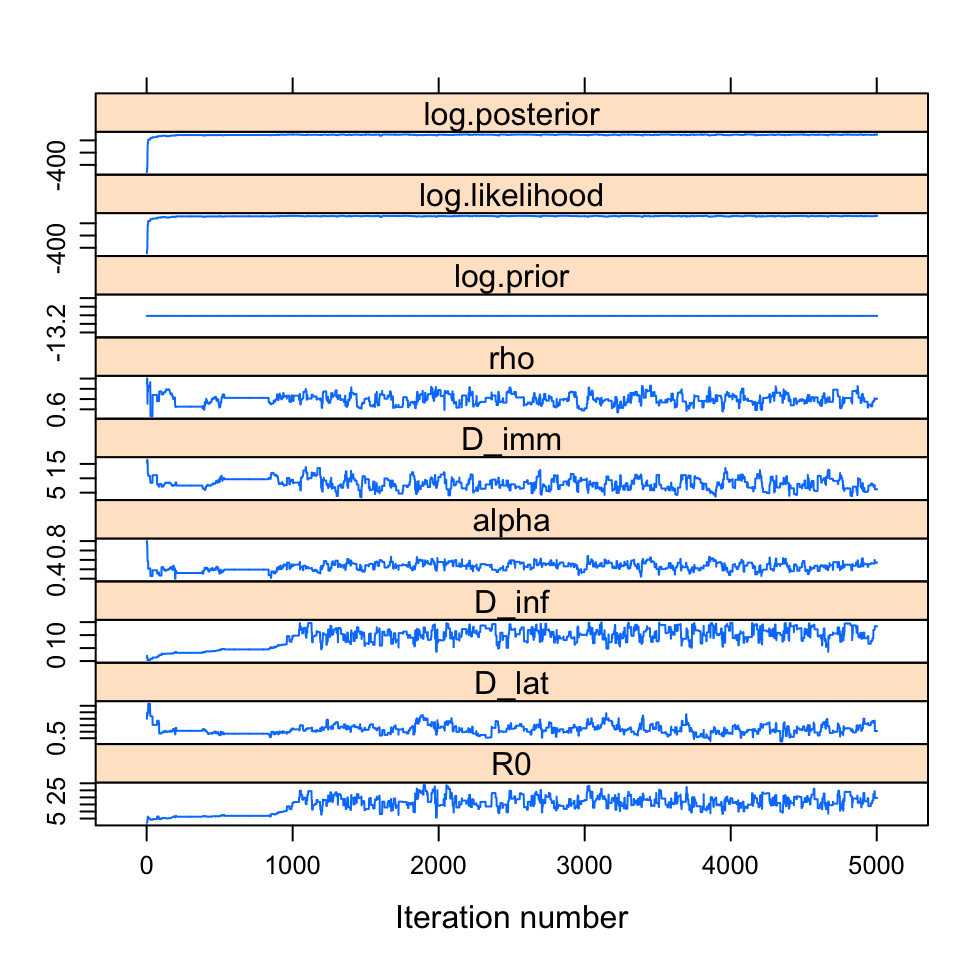

```r
# between 0.1 and 0.6: looks good!

# let's have a look at the traces
xyplot(x = trace)
```

Although the chain was started at a `init.theta` with a low posterior density, it quickly finds the region of the parameter space with high posterior density. Note also the constant trace of the log-prior since we have assumed a uniform prior.

Overall, it looks like the chain reached its target distribution after 1000 steps.

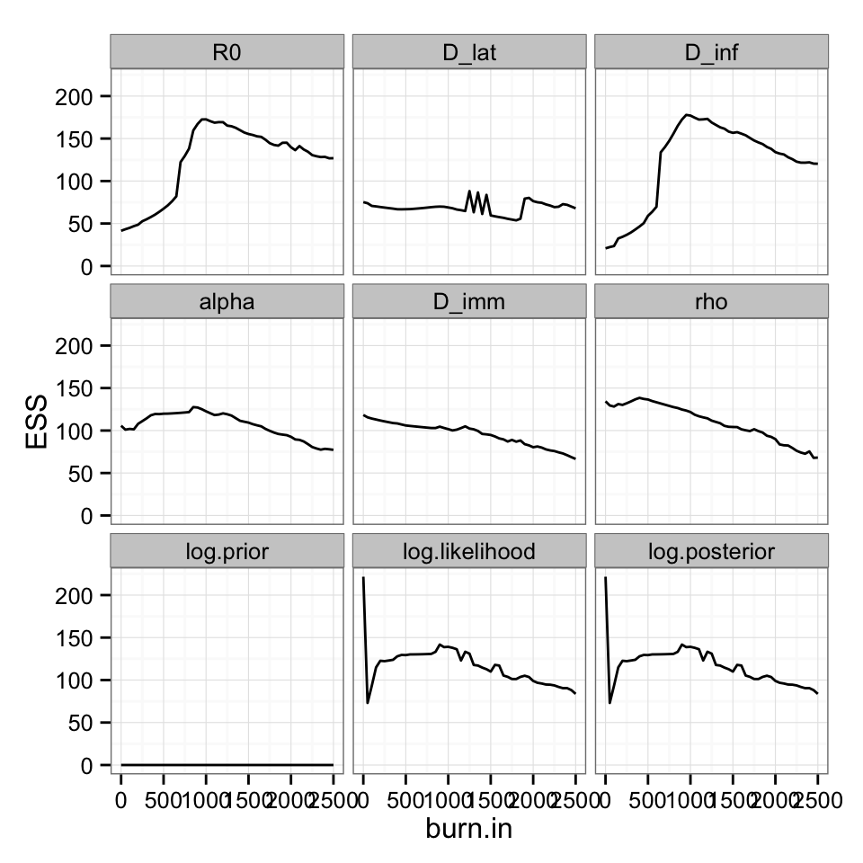

```r
# Let's find a suitable burning:
plotESSBurn(trace)
```

As anticipated from the trace, burning the first 1000 iterations maximizes the effective sample size (ESS).

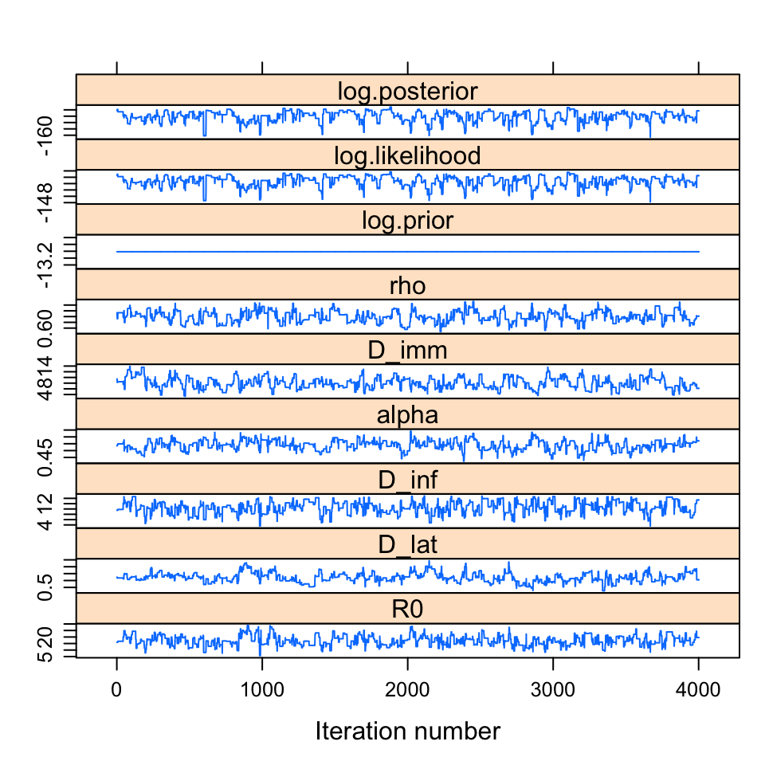

```r
# Let's create a new trace without the burning
trace.burn <- burnAndThin(trace, burn = 1000)
xyplot(x = trace.burn)
```

```r
# Let's check the ESS
effectiveSize(trace.burn)
```

```
##             R0          D_lat          D_inf          alpha          D_imm
##      172.59406       68.90601      177.05769      122.62280      101.66500
##            rho      log.prior log.likelihood  log.posterior
##      121.77874        0.00000      139.10356      139.10356
```

Although we have 4000 samples remaining after burning, the ESS is much smaller. This is due to autocorrelation of the chain.

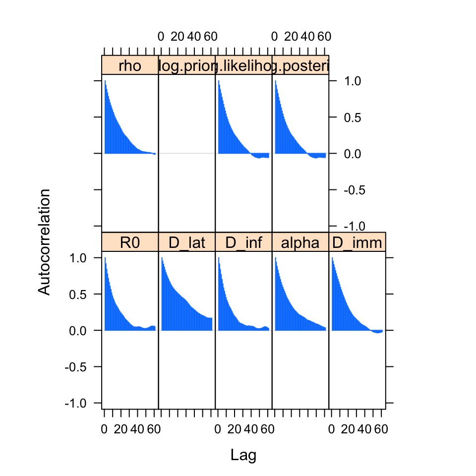

```r
# autocorrelation plot
acfplot(x = trace.burn, lag.max = 60)
```

The autocorrelation between samples drops substantially for a lag of 20 iterations. We can thin the trace to reduce the autocorrelation.

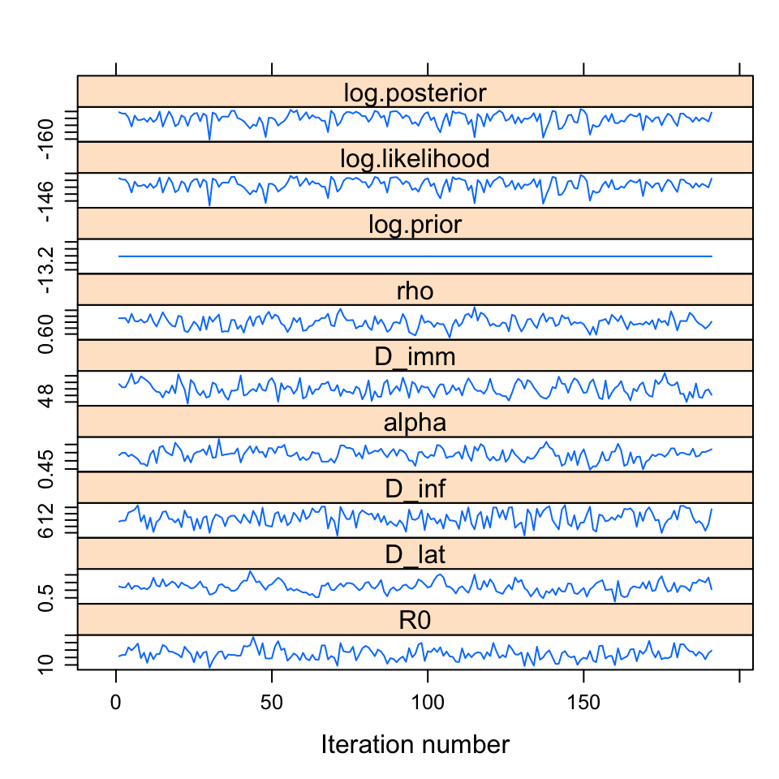

```r
# Let's create a thinned trace
trace.burn.thin <- burnAndThin(trace.burn, thin = 20)
xyplot(x = trace.burn.thin)
```

```r
# Let's check the ESS
effectiveSize(trace.burn.thin)
```

```
##             R0          D_lat          D_inf          alpha          D_imm
##      131.26654       66.87189      191.00000       86.83456      112.46448
##            rho      log.prior log.likelihood  log.posterior
##       96.40768        0.00000      137.34214      137.34214
```

Although the thinned trace has 20 times less fewer than the unthinned trace, it has a similar ESS. This is because the autocorrelation has been reduced.

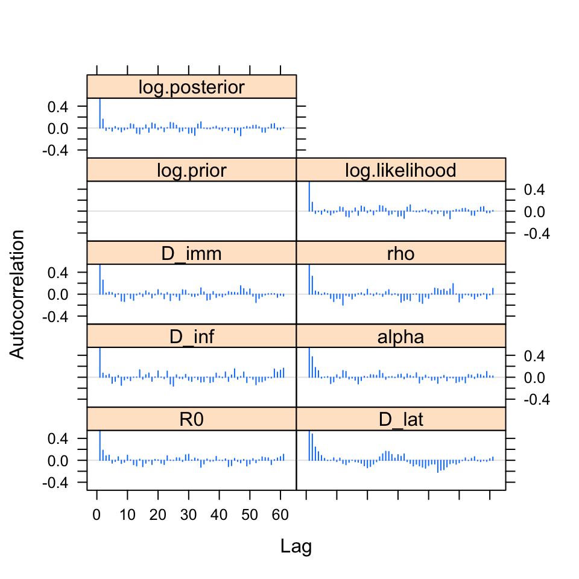

```r
# new autocorrelation plot
acfplot(x = trace.burn.thin, lag.max = 60)
```

Let's compare the posterior estimates of the thinned and unthinned traces.

```r
summary(trace.burn)
```

```
##
## Iterations = 1:4001
## Thinning interval = 1
## Number of chains = 1
## Sample size per chain = 4001
##
## 1. Empirical mean and standard deviation for each variable,
##    plus standard error of the mean:
##
##                     Mean      SD  Naive SE Time-series SE
## R0               17.2400 3.86076 0.0610363       0.293873
## D_lat             1.2168 0.33682 0.0053249       0.040576
## D_inf            10.5268 2.27555 0.0359751       0.171013
## alpha             0.5394 0.03628 0.0005736       0.003276
## D_imm             8.0693 1.97092 0.0311591       0.195471
## rho               0.6998 0.04898 0.0007744       0.004439
## log.prior       -12.8145 0.00000 0.0000000       0.000000
## log.likelihood -141.2841 1.68954 0.0267106       0.143252
## log.posterior  -154.0985 1.68954 0.0267106       0.143252
##
## 2. Quantiles for each variable:
##
##                     2.5%       25%       50%      75%     97.5%
## R0                9.8968   14.4880   16.8702   19.586   24.8133
## D_lat             0.5709    0.9951    1.1892    1.423    1.9408
## D_inf             5.9743    8.8864   10.6053   12.226   14.4630
## alpha             0.4677    0.5150    0.5406    0.565    0.6044
## D_imm             4.4876    6.5216    7.8916    9.520   12.0038
## rho               0.6082    0.6674    0.6995    0.735    0.7919
## log.prior       -12.8145  -12.8145  -12.8145  -12.814  -12.8145
## log.likelihood -145.3254 -142.3281 -141.0061 -139.928 -138.9663
## log.posterior  -158.1398 -155.1425 -153.8206 -152.743 -151.7808
```

```r
summary(trace.burn.thin)
```

```
##
## Iterations = 1:191
## Thinning interval = 1
## Number of chains = 1
## Sample size per chain = 191
##
## 1. Empirical mean and standard deviation for each variable,
##    plus standard error of the mean:
##
##                     Mean      SD Naive SE Time-series SE
## R0               17.3988 3.85418 0.278878       0.336399
## D_lat             1.2195 0.33718 0.024398       0.041233
## D_inf            10.6031 2.24883 0.162720       0.162720
## alpha             0.5389 0.03511 0.002541       0.003768
## D_imm             8.0310 1.98373 0.143538       0.187058
## rho               0.6987 0.04730 0.003423       0.004818
## log.prior       -12.8145 0.00000 0.000000       0.000000
## log.likelihood -141.2704 1.69755 0.122830       0.144851
## log.posterior  -154.0848 1.69755 0.122830       0.144851
##
## 2. Quantiles for each variable:
##
##                     2.5%       25%       50%       75%     97.5%
## R0               10.0298   14.6419   17.1295   19.6005   24.7571
## D_lat             0.5684    1.0116    1.1961    1.4486    1.9094
## D_inf             6.3118    9.1569   10.5184   12.4720   14.2501
## alpha             0.4685    0.5176    0.5402    0.5620    0.5992
## D_imm             4.4508    6.5154    7.8623    9.5462   11.7747
## rho               0.6094    0.6675    0.7011    0.7334    0.7807
## log.prior       -12.8145  -12.8145  -12.8145  -12.8145  -12.8145
## log.likelihood -145.3972 -142.1858 -140.9833 -139.8503 -138.9644
## log.posterior  -158.2117 -155.0003 -153.7978 -152.6648 -151.7789
```

They are very similar. So why thin? Because autocorrelation produces clumpy samples that are unrepresentative, in the short run, of the true underlying posterior distribution. We can check this by comparing the thinned and unthinned distributions using the function `plotPosteriorDensity` of the `fitR` package:

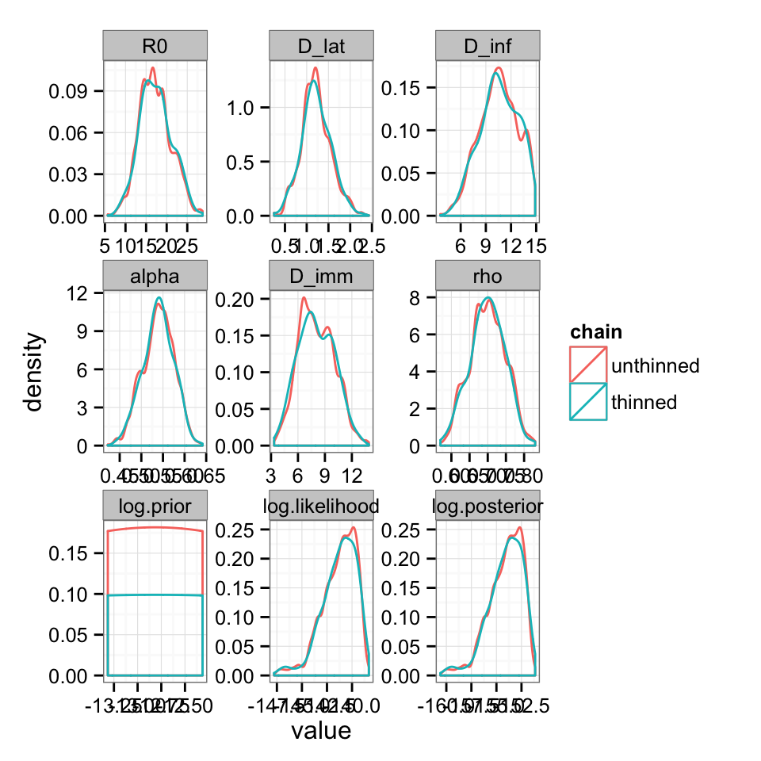

```r
plotPosteriorDensity(list(unthinned = trace.burn, thinned = trace.burn.thin))
```

The thinned trace shows a smoother distribution despite having less samples than the unthinned one. This because the local "bumps" of the unthinned distribution are caused by autocorrelated samples.

You can now go back to the practical and perform a similar analysis for a long-run MCMC.